# Probabilidade

```
[1] "pt_BR/pt_BR/pt_BR/C/pt_BR/C"
```

## Restante das aulas

1. 04/06 - Probabilidade
2. 11/06 - Teste de Hipóteses (Paramétricos & Não-paramétricos)
3. 18/06 - Componentes Principais, Mineração de Padrões Frequentes
4. 25/06 - Programação Funcional, formatos de arquivos, acesso a bancos SQL

## Distribuições de Probabilidade

- De maneira bastante informal, as distribuições de probabilidade são listas de valores possíveis com suas probabilidades associadas.
- O conjunto de valores pode ser discreto quando os possíveis resultados forem contáveis (enumeráveis) ou contínuo caso contrário.
  - Distribuições de variáveis aleatórias contínuas são descritas por uma [Função de Densidade de Probabilidade](https://pt.wikipedia.org/wiki/Fun%C3%A7%C3%A3o_densidade).
  - Distribuições de variáveis aleatórias discretas são descritas por uma [Função de Massa de Probabilidade](https://pt.wikipedia.org/wiki/Fun%C3%A7%C3%A3o_massa_de_probabilidade).

Distribuições descritas por funções são conhecidas como Distribuições Paramétricas. As suas funções possuem parâmetros que estabelecem os valores possíveis e suas probabilidades.

## Distribuições mais conhecidas / utilizadas

#### Uniforme (Variável Discreta e Variável Contínua)

- A distribuição Uniforme atribui a mesma probabilidade para cada valor possível entre um mínimo e um máximo. Apesar de não possuir parâmetros, costuma ser definida por $b=max$, $a=min$.
- Valor esperado: (max + min) / 2

##### Exemplo:

Simulação de Jogo de Dados com 10.000 repetições. Cada face tem igual probabilidade, de $\dfrac{1}{6} = 0.166\overline6$, e o valor esperado é $\dfrac{6 + 1}{2} = 3.5$

```r
set.seed(201806)
(tb_dados <- table(purrr::rdunif(10000, a=1, b=6)))
```

Proporcionalmente:

```r
prop.table(tb_dados)
```

```
     1      2      3      4      5      6
0.1722 0.1579 0.1675 0.1680 0.1685 0.1659
```

### Variáveis aleatórias discretas

#### Bernoulli

Probabilidade $p$ de Sucesso / Fracasso, onde $p$ é o parâmetro da função.

- Um jogo de Cara ou Coroa com moeda não viciada é descrito por uma distribuição de Bernoulli com parâmetro $p=0,5$.
- A probabilidade global de uma pessoa ser destra é de 90%, descrita por uma distribuição de Bernoulli com parâmetro $p=0,9$.
  - Essa mesma proporção já foi observada em exames ultrassom.
- A probabilidade de um brasileiro ser destro é de 96%, descrita por uma distribuição de Bernoulli com parâmetro $p=0,96$.

Em R, simulamos uma distribuição de Bernoulli através da função `rbernoulli`, cujos parâmetros são a quantidade de eventos e a probabilidade do parâmetro $p$. Como o processo de Bernoulli é formado por saídas binárias (acerto/erro, 0/1, cara/coroa) a função retorna um vetor de valores lógicos.

Seu valor esperado é definido por $p$, e a Variância é definida por $p\times(1 - p)$

```r
x <- 1:7
options(scipen=999)

set.seed(201806)

(bern <-
  data_frame(Pessoas = 10 ^ x) %>%
  mutate( Destros = map_int(Pessoas, ~ sum(rbernoulli(.x, p = 0.9))) ) %>%
  mutate( Canhotos = Pessoas - Destros))
```

Considerando o intervalo de 1 desvio padrão em torno da média, a proporção de destros no Brasil está dentro do esperado em relação à proporção global?

```r
prob_destro_global <- 0.9
variancia_prob_destro <- prob_destro_global * (1 - prob_destro_global)

lo_int <- prob_destro_global - sqrt( variancia_prob_destro )
hi_int <- prob_destro_global + sqrt( variancia_prob_destro )

between(0.96, lo_int, hi_int)
```

Essa análise diretamente sobre as proporções faz sentido?

#### Binomial

- Distribuição do número $k$ de sucessos/acertos de um processo de Bernoulli após $n$ eventos.

**Importante:** Os exemplos abaixo assumem que as observações utilizadas são amostras independentes. Canhotismo tem a ver com hereditariedade e mesmo uma insistência familiar/social pelo uso da mão direita.

```r
prob_destro_brasil <- 0.96
amostra_populacao <- 100000
variancia_prob_destro <- prob_destro_brasil * (1 - prob_destro_brasil) * amostra_populacao
sd_prob_destro_brasil <- sqrt( variancia_prob_destro )

lo_sd <- 96000 - (2 * sd_prob_destro_brasil)
hi_sd <- 96000 + (2 * sd_prob_destro_brasil)

range_prop_destros <- seq(from=95500, to=96500, by=10)

# Para fechar em 100% tive que multiplicar a densidade (probabilidade) por 10, pois o intervalo foi de 10 em 10
df_binom_probs <- data_frame(x = range_prop_destros, y=dbinom(x, size = 100000, prob = prob_destro_brasil) * 10)

ggplot(df_binom_probs, aes(x, y=cumsum(y))) +
  geom_line() +
  scale_x_continuous(breaks = seq(from=95500, to=96500, by=100)) +
  geom_vline(xintercept = lo_sd, alpha=0.5, linetype = "dashed") +
  geom_label(x = lo_sd, y=1.0, label = round(lo_sd, 0)) +
  geom_vline(xintercept = hi_sd, alpha=0.5, linetype = "dashed") +
  geom_label(x = hi_sd, y=0.0, label = round(hi_sd, 0)) +
  labs(x = "Destros", y= "Probabilidade Acumulada") +
  theme_bw() +
  theme(axis.text.x = element_text(angle = 45, hjust = 1))
```

[output not shown]

- Considere uma cidade com 100 mil habitantes. Qual a probabilidade de a cidade ter 96,1 mil destros ou mais quando a probabilidade esperada é de 96%?

```r
pbinom( 96100, size = 100000, prob = 0.96, lower.tail = FALSE )
```

##### Pausa

- Canhoto/Destro é mesmo uma variável categórica?
  - [Edinburgh Handedness Inventory](https://en.wikipedia.org/wiki/Edinburgh_Handedness_Inventory)

#### Poisson

- A distribuição de Poisson descreve o comportamento do número de eventos que ocorrem em um espaço determinado de tempo.
  - Quantidade de carros que passam em uma rodovia por hora,
  - Quantidade de produtos vendidos em um dia, etc.
- A distribuição de Poisson é definida pelo parâmetro $lambda$, que determina também o valor esperado (média) e a variância de uma distribuição de Poisson.
- Por exemplo, um produto cuja venda diária é descrita por uma distribuição de Poisson com $lambda=18$ vendeu somente 10 unidades no dia de hoje. Qual a probabilidade deste produto vender até o máximo de 10 unidades dado o histórico de vendas do produto?

```r
paste0(round(ppois(10, lambda = 18) * 100, 2), '%')
```

- Qual o valor máximo de venda diária esperada para este produto? (100% de probabilidade)

```r
qpois(1, lambda = 18, lower.tail = TRUE)
```

- Assume-se uma probabilidade de 99,9%

```r
qpois(1 - 0.001, lambda = 18, lower.tail = TRUE)
```

- Qual a menor quantidade esperada dada esta mesma possibilidade (agora de 0.1%)?

```r
qpois(0.001, lambda = 18, lower.tail = TRUE)
```

- Qual a distribuição de probabilidades?

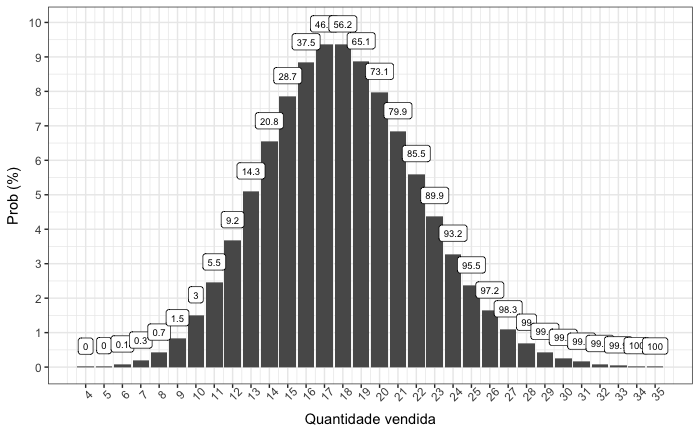

#### Geométrica

- Modela o tempo de espera até o primeiro sucesso de uma sequência de ensaios de Bernoulli. Tal como as distribuições de Bernoulli e Binomial, é parametrizada por $p$.
- Quantas coroas em sequência até obter uma cara?
  - Lembrando que cada arremesso tem igual probabilidade, independente do resultado anterior.

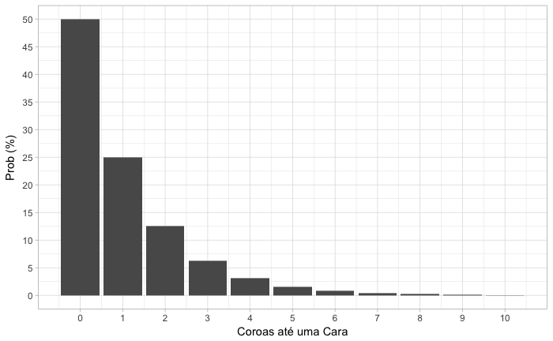

```r
# Vamos comparar a tabela com a distribuição de probabilidades plotada acima
round( prop.table( table(seq_head_tails$lengths[!seq_head_tails$values]) ), 2)
```

```
   1    2    3    4    5    6    7    8
0.49 0.27 0.10 0.06 0.04 0.02 0.01 0.01
```

- Comparada com a Distribuição Binomial:
  - Binomial: Quantos eventos de sucesso?
  - Geométrica: Quantas falhas até o sucesso?

Se você ligar para a operadora em um dia de queda de conectividade de internet você tem 10% de chance de ser atendido a cada ligação. Qual a probabilidade de você ter sua oportunidade de reclamar após 6 ligações frustradas?

```r
pgeom(6, prob=0.1, lower.tail = TRUE)
```

```
[1] 0.5217031
```

ATIVIDADE 01 :: Faça o gráfico da distribuição de probabilidades de chamadas telefônicas até 20 ligações e simule 500 eventos de Bernoulli para esta mesma probabilidade. Nesta simulação, identifique quantas sequências de 6 falhas ocorreram. Use como *seed* os últimos 5 dígitos da sua matrícula. Veja no exemplo anterior o uso da função `rle`.

ATIVIDADE 02 ::

- Você criou um sistema para reclamações da demora do atendimento de ligações telefônicas durante quedas de conectividade da Internet e exige que os usuários acertem um CAPTCHA antes de postarem uma reclamação. Você observou que a probabilidade de um usuário acertar o CAPTCHA exibido no seu sistema é de 70%.
- Seu sistema de monitoramento identificou que um usuário tentou 5 CAPTCHAS diferentes antes de conseguir reclamar do tempo de atendimento na última queda de conectividade.
  - Qual a probabilidade de um usuário acertar o CAPTCHA após 5 tentativas fracassadas? Qual o mínimo de tentativas para que a probabilidade seja maior que 50%?
  - Você observou que, das últimas 500 *tentativas* de publicação de reclamações, 340 acertaram a validação de CAPTCHA. Qual a probabilidade de uma quantidade entre 320 e 350 tentativas passarem pela validação de CAPTCHA a cada 500 tentativas? Dada a probabilidade de 70% de sucesso, qual o número esperado de publicações a cada 500 CAPTCHAS? DICA: ESTAMOS TRATANDO DA DISTRIBUIÇÃO BINOMIAL.

### Variáveis aleatórias contínuas

#### Gaussiana

- A mais conhecida dentre as distribuições de probabilidade. Conhecida também como distribuição Normal ou “curva de sino”.
- O que a torna tão relevante?
  - [Teorema Central do Limite](https://pt.wikipedia.org/wiki/Teorema_central_do_limite)
- Seus parâmetros, $\mu$ e $\sigma$ conectam-se facilmente com as médias e desvio padrão calculados.

Ranking global de alturas

- [Brasileiro cresce em altura nos últimos cem anos, mas ainda é ‘baixinho’; conheça o ranking global](http://g1.globo.com/ciencia-e-saude/noticia/2016/07/brasileiro-cresce-em-altura-nos-ultimos-cem-anos-mas-ainda-e-baixinho-conheca-o-ranking-global.html)
- Estudo publicado [A century of trends in adult human height](https://elifesciences.org/articles/13410)
- Dados disponíveis [para download](http://ncdrisc.org/data-downloads-height.html)

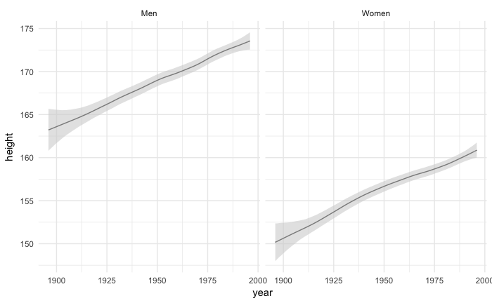

> > ATIVIDADE EM AULA
1. Utilizando o data frame br_height e as operações do pacote **dplyr** (**tidyverse**), selecione os dados de altura (height), menor altura dentro do IC (lo_95) e maior altura dentro do IC (hi_95) de acordo com o seu sexo e ano de nascença. Crie uma variável que é a divisão de sua altura pela média, e outra que informa se a sua altura está dentro ou fora do intervalo de confiança. Em aula, informe o professor sobre os 2 resultados.
2. Baixe o relatório do [LEVANTAMENTO DO PERFIL ANTROPOMÉTRICO DA POPULAÇÃO BRASILEIRA USUÁRIA DO TRANSPORTE AÉREO NACIONAL – PROJETO CONHECER](http://www2.anac.gov.br/arquivos/pdf/Relatorio_Final_Projeto_Conhecer.pdf) e obtenha a média e o desvio padrão da amostra deste relatório (página 23).
3. Considerando que o estudo da ANAC foi realizado entre os anos de 2004 e 2008, e que a média de idade é de 40 anos, com Desvio Padrão de idade de 12 anos, e assumindo como premissa que a altura da pessoa se mantem entre os 20 e os 60 anos, temos um intervalo de aproximadamente 1.65 desvios padrão da média. Utilizando a função `pnorm`, calcule os percentuais de 20 anos e 60 anos com a média (mean), e desvio padrão (sd) obtidos neste relatório. Utilize o parâmtro `lower.tail = FALSE` para 60 anos e `lower.tail = TRUE` para 20 anos. Quais são os valores obtidos? Conclua quanto representa, em percentual, os 1.65 desvios padrão.
4. Assumindo que a altura aos 18 anos equivale à altura dos 20 aos 60 anos, selecione do data frame br_height a altura média de todas as pessoas que tinham entre 20 e 60 anos entre os anos de 2004 e 2008. Calcule a média de altura de homens e de mulheres neste período. Realize todo este exercício utilizando o **dplyr**. Responda: Com base nas alturas médias obtidas, você acha que mulheres participaram deste estudo?
5. A altura média dos homens calculada no exercício 4 está quantos desvios-padrão acima/abaixo da média anotada no exercício 2?
6. Baixe os seguintes arquivos:
- [Antropometria e estado nutricional de crianças, adolescentes e adultos no Brasi](https://ww2.ibge.gov.br/home/estatistica/populacao/condicaodevida/pof/2008_2009_encaa/defaulttabzip_brasil.shtm), baixe o arquivo Tabela Completa Brasil.
- [link de tabelas por UF](https://ww2.ibge.gov.br/home/estatistica/populacao/condicaodevida/pof/2008_2009_encaa/defaulttabzip_UF.shtm), baixe a tabela dos estados do Rio Grande do Sul e do Sergipe.
7. Calcule a média ponderada da altura dos homens a partir de 18 anos até o grupo de 45 a 54 anos para os 3 arquivos.
8. Para cada arquivo, determine a quantidade de grupos de idade que estão abaixo da média obtida no exercício 2.

> > FIM ATIVIDADE